# WSP MvF Analyses

2024-02-14

# Set up workspace

```r
# Set directory for knitr to save the html
knitr::opts_knit$set(root.dir = "C:/Users/mnale/OneDrive - University of North Carolina at Chapel Hill/WSP Proteomics Project")
```

# Load packages and datasets.

```r
# Load packages
library(readxl) # for reading in files
library(openxlsx) # for writing excel files
library(purrr) # for summary stats
library(tidyverse) # for data organization and manipulation
library(ggrepel) # for ggplot text labels
library(eulerr) # for venn diagrams
library(cowplot) # for plot themes
library(janitor) # for df cleaning

# Read in files.
original_proteomics_df <- read.csv("C:/Users/mnale/OneDrive - University of North Carolina at Chapel Hill/WSP Proteomics Project/data/011023_Processed_Proteomics_Data.csv")
demographics <- read_excel("C:/Users/mnale/OneDrive - University of North Carolina at Chapel Hill/WSP Proteomics Project/data/Demographics_Data_R.xlsx")
```

# Import data and perform initial cleaning steps

```r
proteomics_df = original_proteomics_df %>%
  separate(Subject_ID, c("Responder_Status", "ID"), sep = "_") %>%
  separate(Sample_ID, c("Pre_Post", NA), sep = "_") %>%
  separate(Protein_Name, c("Protein_Name", NA), sep = "_") %>%
  rename("Non_Imputed_Intensity" = "Intensity") %>%
  rename("Intensity" = "Imputed_Norm_Intensity")

# We will only study log2 transformed data.
proteomics_df$Log2_Intensity <- log2(proteomics_df$Intensity)

# Merge proteomics data with the demographics data.
proteomics_df <- merge(proteomics_df, demographics, by = "ID")

head(proteomics_df)
```

```
##   ID Protein_Accession Gene_Name
## 1  1            P61626       LYZ
## 2  1            P61626       LYZ
## 3  1            P30048     PRDX3
## 4  1            P62195     PSMC5
## 5  1            P51991   HNRNPA3
## 6  1            Q9NP79      VTA1
##                                       Protein_Descriptions Protein_Name
## 1                                               Lysozyme C         LYSC
## 2                                               Lysozyme C         LYSC
## 3  Thioredoxin-dependent peroxide reductase, mitochondrial        PRDX3
## 4                      26S proteasome regulatory subunit 8         PRS8
## 5               Heterogeneous nuclear ribonucleoprotein A3         ROA3
## 6 Vacuolar protein sorting-associated protein VTA1 homolog         VTA1
##   Number_Unique_Peptides Responder_Status Pre_Post Non_Imputed_Intensity
```

[output cut: 20 more lines]

Make a smaller dataframe to use for future plots.

```r
proteomics_short <- proteomics_df %>%
  select(c(ID, Protein_Name, Pre_Post, Log2_Intensity, Sex)) %>%
  pivot_wider(names_from = Pre_Post, values_from = Log2_Intensity)

# Save dataframe
write.xlsx(proteomics_short,"../output_FINAL/proteomics_short_11.06.2023.xlsx")
```

Separate into two data frames: one for Pre intensity and another for Post intensity.

```r
pre <- proteomics_df %>%
  filter(Pre_Post == "Pre") %>%
  pivot_wider(names_from = Pre_Post, values_from = Log2_Intensity)

post <- proteomics_df %>%
  filter(Pre_Post == "Post") %>%
  pivot_wider(names_from = Pre_Post, values_from = Log2_Intensity)
```

# Test for normality and homogeneity of variances

Create a new df holding Pre- and Post- protein intensity values and make a new column subtracting Pre- from Post-.

```r
pre_short <- select(pre, c(ID, Protein_Name, Pre))
post_short <- select(post, c(ID, Protein_Name, Post))

# Merge the new ds together.
Var_Test <- merge(pre_short, post_short, by = c("ID", "Protein_Name"))

# Create a new column that determines the Post minus Pre intensity for each protein across each subject.
Var_Test$Delta <- (Var_Test$Post - Var_Test$Pre)
```

## Perform the Shapiro-Wilk test and F-Test

Shapiro-Wilk test: if the test is non-significant (p>.05) it tells us that the distribution of the sample is not significantly different from a normal distribution.

F-test: using var.test(), if the p-value > 0.05 significance, there is no significant difference between the two variances.

```r
# The 'proteins' list will hold unique protein names that we will use for the upcoming loop function.
proteins <- unique(proteomics_df$Protein_Name)

# Create an empty dataframe for the loop function to place values into.
SW.F_Res <- data.frame()

for (i in 1:length(proteins)) {

  # Select only protein[i]
  Prot_Filtered <- Var_Test %>%
    filter(Protein_Name == proteins[i])

  # Run the Shapiro-Wilk test across the mean protien 'Delta' from Pre and Post across all subjects
  SW <- shapiro.test(Prot_Filtered$Delta)

  # Run the F-test across mean Pre and Post across all subjects
  F_test <- var.test(Prot_Filtered$Pre, Prot_Filtered$Post)

  # Isolate the p-value list from each test.
  SW_pval <- SW$p.value

  F_pval <- F_test$p.value

  # Isolating proteins names to include in the final df.
  Protein_Name <- proteins[i]

  # Merge the Protein names and p-values into a new df.
  res <- data.frame(Protein_Name, SW_pval, F_pval)

  # Merge the 'res' df with the empty dataframe 'Var_Res'.
  SW.F_Res <- rbind(res, SW.F_Res)

}

# Make a column that indicates if each protein has normal distribution.
SW.F_Res$Normal_Dist <-
  case_when(
    SW.F_Res$SW_pval < 0.05 ~ "No",
    SW.F_Res$SW_pval > 0.05 ~ "Yes")

# Make a column that indicates if each protein has significant difference between the Pre and Post variances.
SW.F_Res$Homogeneity <-
  case_when(
    SW.F_Res$F_pval < 0.05 ~ "No",
    SW.F_Res$F_pval > 0.05 ~ "Yes")

# Save results.
write.xlsx(SW.F_Res,"../output_FINAL/SW_and_F.Test_Results_11.06.2023.xlsx")
```

## Assessing normality and homogeneity of variance

Determine how many proteins have variances that are normally distributed and exhibit homogeneity of variance.

```r
# Number of normally distributed proteins.
length(which(SW.F_Res$Normal_Dist == "Yes")) # 1553 proteins are normally distributed
```

```
## [1] 1553
```

```r
length(which(SW.F_Res$Normal_Dist == "No")) # 301 proteins are not normally distributed.
```

```
## [1] 301
```

```r
# Number of proteins that exhibit homogeneity of variance.
length(which(SW.F_Res$Homogeneity == "Yes")) # 1794 proteins exhibit homogeneity of variance
```

```
## [1] 1794
```

```r
length(which(SW.F_Res$Homogeneity == "No")) # 60 proteins exhibit homogeneity of variance
```

```
## [1] 60
```

```r
# How many proteins answer "Yes" to each condition:
length(which(SW.F_Res$Normal_Dist == "Yes" & SW.F_Res$Homogeneity == "Yes")) # 1508 Proteins.
```

```
## [1] 1508
```

```r
# How many proteins answer "no" to each condition:
length(which(SW.F_Res$Normal_Dist == "No" & SW.F_Res$Homogeneity == "No")) # 15 Proteins.
```

```
## [1] 15
```

```r
# A majority of proteins exhibit normal distribution and homogeneity of variance. We will proceed with statistical testing that assumes normality.
```

## Aggregate Summary Statistics

Create dataframes holding means and standard deviations of all subjects Pre- and Post-.

First, generate means and sds of each protein Pre- and Post- separately.

```r
# Create a list of proteins that the loop function will assess.
proteins <- unique(proteomics_df$Protein_Name)

# Create an empty dataframe for the loop function to place values into.
Prot_Means <- data.frame()

for (i in 1:length(proteins)) {

  Pre_Filtered <- pre %>%
    filter(Protein_Name == proteins[i])

  Post_Filtered <- post %>%
    filter(Protein_Name == proteins[i])

  # Make list objects that hold the mean and sd values.
  Pre_Mean_Intensity <- mean(Pre_Filtered$Intensity)
  Pre_SD <- sd(Pre_Filtered$Intensity)

  Post_Mean_Intensity <- mean(Post_Filtered$Intensity)
  Post_SD <- sd(Post_Filtered$Intensity)

  # Isolating proteins names to include in the final df.
  Protein_Name <- proteins[i]

  # Merge the Protein names with means and sds into a new df.
  res <- data.frame(Protein_Name, Pre_Mean_Intensity, Pre_SD, Post_Mean_Intensity, Post_SD)

  # Merge the res df with the empty df.
  Prot_Means <- rbind(res, Prot_Means)

}

head(Prot_Means)
```

```
##   Protein_Name Pre_Mean_Intensity    Pre_SD Post_Mean_Intensity   Post_SD
## 1        K2C78           563141.3 1405634.8            899518.7 1878963.6
## 2         B2MG           649385.4  246851.7            636541.0  362393.4
## 3         HEMO           639896.6  355433.6            594169.8  584774.5
## 4         CYTD           648552.1  714727.6            594330.3  544982.9
## 5          HBB           556878.3 1054032.7            449779.2 1191806.8
## 6         PERM           600187.9  659282.2            731506.7  664915.4
```

```r
# Save results.
write.xlsx(Prot_Means, "../output_FINAL/Prot_Means_11.06.2023.xlsx")
```

# T-Tests and Fold Change Calculations

## T-Tests

T-tests comparing the **Pre** intensity of each protein for male vs female subjects.

```r
# Make new dfs that isolate for only males or females.
M_pre <- pre %>%
  filter(Sex == "M")

F_pre <- pre %>%
  filter(Sex == "F")

# Create a list of proteins that the loop function will assess.
proteins <- unique(proteomics_df$Protein_Name)

#create an empty dataframe for the loop function to place values into.
Pre_MvF_mean_ttest <- data.frame()

for (i in 1:length(proteins)) {

  M_pre_t <- M_pre %>%
    filter(Protein_Name == proteins[i])

  F_pre_t <- F_pre %>%
    filter(Protein_Name == proteins[i])

  # Make list objects that hold the mean and sd values.
  M_Pre_Mean <- mean(M_pre_t$Pre)
  M_Pre_SD <- sd(M_pre_t$Pre)

  F_Pre_Mean <- mean(F_pre_t$Pre)
  F_Pre_SD <- sd(F_pre_t$Pre)

  # Perform the T-Test
  ttest_M.F <- t.test(M_pre_t$Pre, F_pre_t$Pre)

  # Isolate p-values.
  pval_M.F <- ttest_M.F$p.value

  # Isolating proteins names to include in the final df.
  Protein_Name <- proteins[i]

  # Merge the Protein names and p-values into a new df.
  res <- data.frame(Protein_Name, M_Pre_Mean, M_Pre_SD, F_Pre_Mean, F_Pre_SD, pval_M.F)

  # Merge the res df with the empty df.
  Pre_MvF_mean_ttest <- rbind(res, Pre_MvF_mean_ttest)

}

# FDR
Pre_MvF_mean_ttest$p.adj <-  p.adjust(Pre_MvF_mean_ttest$pval_M.F, "fdr")

# Save results.
write.xlsx(Pre_MvF_mean_ttest,"../output_FINAL/Pre_MvF_mean_ttest_11.06.2023.xlsx")
```

This loop will also generate T-tests across each protein for Pre **and** Post across all subjects and also also stratifying by sex. Final df will include means and sds as well.

```r
# Make new dfs that isolate for only males or females.
M_pre.post <- proteomics_short %>%
  filter(Sex == "M")

F_pre.post <- proteomics_short %>%
  filter(Sex == "F")

# Create a list of proteins that the loop function will assess.
proteins <- unique(proteomics_df$Protein_Name)

#create an empty dataframe for the loop function to place values into.
ttest_mean_res <- data.frame()

for (i in 1:length(proteins)) {

  # Isolate data only for the relevant Protein_Name in the loop.
  All_filtered <- proteomics_short %>%
    filter(Protein_Name == proteins[i])

  M_filtered <- M_pre.post %>%
    filter(Protein_Name == proteins[i])

  F_filtered <- F_pre.post %>%
    filter(Protein_Name == proteins[i])

  # Make list objects that hold the mean and sd values.
  Pre_Mean <- mean(All_filtered$Pre)
  Pre_SD <- sd(All_filtered$Pre)

  Post_Mean <- mean(All_filtered$Post)
  Post_SD <- sd(All_filtered$Post)

  M_Pre_Mean <- mean(M_filtered$Pre)
  M_Pre_SD <- sd(M_filtered$Pre)
  M_Post_Mean <- mean(M_filtered$Post)
  M_Post_SD <- sd(M_filtered$Pre)

  F_Pre_Mean <- mean(F_filtered$Pre)
  F_Pre_SD <- sd(F_filtered$Pre)
  F_Post_Mean <- mean(F_filtered$Post)
  F_Post_SD <- sd(F_filtered$Post)

  # Runs T-tests on Pre vs Post across all subjects, then Pre vs Post by sex.
  All_ttest <- t.test(All_filtered$Pre, All_filtered$Post, paired = TRUE)
  M_ttest <- t.test(M_filtered$Pre, M_filtered$Post, paired = TRUE)
  F_ttest <- t.test(F_filtered$Pre, F_filtered$Post, paired = TRUE)

  # Isolate p-value from ttest_res to place in ttest_pre.post later in the chunk.
  Pval <- All_ttest$p.value
  M_Pval <- M_ttest$p.value
  F_Pval <- F_ttest$p.value

  # This list will be used to add the appropriate protein name to ttest_pre.post.
  Protein_Name <- proteins[i]

  # Put all needed values into a df that we will bind to the empty ttest_pre.post df.
  res <- data.frame(Protein_Name, Pre_Mean, Pre_SD, Post_Mean, Post_SD, Pval, M_Pre_Mean, M_Pre_SD, M_Post_Mean, M_Post_SD, M_Pval, F_Pre_Mean, F_Pre_SD, F_Post_Mean, F_Post_SD, F_Pval)

  ttest_mean_res <- rbind(res, ttest_mean_res)

}

ttest_mean_res$p.adj <-  p.adjust(ttest_mean_res$Pval, "fdr")
ttest_mean_res$M_p.adj <-  p.adjust(ttest_mean_res$M_Pval, "fdr")
ttest_mean_res$F_p.adj <-  p.adjust(ttest_mean_res$F_Pval, "fdr")

# Save results.
write.xlsx(ttest_mean_res,"../output_FINAL/T.Tests_Means_Pre.Post_Complete_06.04.2024.xlsx")
```

## Fold changes

Fold change is defined as FC = Log2(post) - Log2(pre), or in this case FC = post - pre since our data are already log2 transformed.

I will create a df that determines the FC of each protein across each person. I will use this df in future code chunks to summarize the FCs by different metrics.

```r
# Create a list of proteins that the loop function will assess.
proteins <- unique(proteomics_df$Protein_Name)

# Create an empty dataframe for the loop function to place values into.
FC_Complete <- data.frame()

for (i in 1:length(proteins)) {

  # Isolate data only for the relavent Protein_Name in the loop.
  All_filtered <- proteomics_short %>%
    filter(Protein_Name == proteins[i])

  # Calculate the FC
  FC <- All_filtered$Post - All_filtered$Pre

  # This list will be used to add the appropriate protein name to ttest_pre.post.
  Protein_Name <- proteins[i]

  # I will want the ID across each protein FC labeled
  ID <- All_filtered %>%
    select("ID", "Sex") %>%
    unique()

  # Put all needed values into a df that we will bind to the empty ttest_pre.post df.
  res <- data.frame(ID, Protein_Name, FC)

  FC_Complete <- rbind(res, FC_Complete)

}

# Save results.
write.xlsx(FC_Complete,"../output_FINAL/FC_Complete_11.08.2023.xlsx")
```

Now we will generate the FC means across different categories.

```r
# This df will hold the FC means and SDs across all proteins
FC_Mean <- FC_Complete %>%
  group_by(Protein_Name) %>%
  summarise(
    FC_Mean = mean(FC),
    SD = sd(FC)) %>%
  select(c(Protein_Name, FC_Mean, SD))

# This df will hold the FC means and SDs across all proteins by sex stratification
FC_Sex <- FC_Complete %>%
  group_by(Sex, Protein_Name) %>%
  summarise(
    .groups = 'drop',
    FC_Mean = mean(FC),
    SD = sd(FC)) %>%
  pivot_wider(names_from = Sex,
              values_from = c(FC_Mean, SD)) %>%
  rename("F_FC_Mean" = "FC_Mean_F",
         "F_SD" = "SD_F",
         "M_FC_Mean" = "FC_Mean_M",
         "M_SD" = "SD_M")
```

Now we will attach the FC means to the the p-values generated from the T-Test loop.

```r
# Isolate P-values
Pval <- ttest_mean_res %>%
  select(c(Protein_Name, Pval, p.adj))

# Merge the FC means and p-values.
FC_Mean <- merge(FC_Mean, Pval, by = "Protein_Name")

# Isolate P-values corresponding to males and females
Pval_Sex <- ttest_mean_res %>%
  select(c(Protein_Name, F_Pval, F_p.adj, M_Pval, M_p.adj))

# Merge the FC means and p-values.
FC_Sex <- merge(FC_Sex, Pval_Sex, by = "Protein_Name")

# Reorder the columns in FC_Sex
FC_Sex <- FC_Sex %>%
  select(Protein_Name, M_FC_Mean, M_SD, M_Pval, M_p.adj, F_FC_Mean, F_SD, F_Pval, F_p.adj)

# View dfs
head(FC_Mean)
```

```
##   Protein_Name    FC_Mean        SD       Pval     p.adj
## 1        1433B -0.2394893 0.8363187 0.14878609 0.4386030
## 2        1433E -0.2418224 0.8667658 0.15909990 0.4422357
## 3        1433F -0.3518680 1.0154324 0.08338299 0.3933784
## 4        1433G -0.3723403 0.9415176 0.05006384 0.3573739
## 5        1433S  0.2495354 1.6499319 0.43905024 0.6037814
## 6        1433T -0.1441467 1.0796056 0.49397300 0.6403748
```

```r
head(FC_Sex)
```

```
##   Protein_Name   M_FC_Mean      M_SD    M_Pval   M_p.adj  F_FC_Mean     F_SD
## 1        1433B -0.12247715 0.6480729 0.4613887 0.6776053 -0.4096889 1.065244
## 2        1433E -0.13418670 0.7371910 0.4777671 0.6882518 -0.3983834 1.045304
## 3        1433F -0.16771400 0.8058917 0.4182178 0.6565418 -0.6197284 1.254389
## 4        1433G -0.27675486 0.6569980 0.1126809 0.5985292 -0.5113736 1.273355
## 5        1433S  0.03305747 1.4602118 0.9290441 0.9656955  0.5644123 1.922380
## 6        1433T -0.17081826 0.9998443 0.5047869 0.6994581 -0.1053516 1.236163
##      F_Pval   F_p.adj
## 1 0.2309445 0.8459329
## 2 0.2348907 0.8459329
## 3 0.1323412 0.8459329
## 4 0.2124389 0.8459329
## 5 0.3531397 0.8671279
## 6 0.7832031 0.9494024
```

```r
# Save results.
write.xlsx(FC_Mean,"../output_FINAL/FC_Mean_Pval_06.04.2023.xlsx")
write.xlsx(FC_Sex,"../output_FINAL/FC_Sex_Mean_Pval_06.04.2023.xlsx")
```

Make separate dfs for labeling proteins in the volcano plots.

```r
# All subjects
FC_Mean_Top <- FC_Mean %>% # Select for proteins with pval <0.05 and order by the largest FCs
  filter(Pval < 0.05) %>%
  arrange(desc(abs(FC_Mean)))

All_Top10 <- FC_Mean_Top[1:10,] # Select the top 10 proteins
unlist(All_Top10$Protein_Name) # "CXCL6" "MARCO" "GFRP"  "NCEH1" "GPDA"  "PPA5"  "TFR1"  "NNRE"  "ACOC"  "TGM2"
```

```
##  [1] "CXCL6" "MARCO" "GFRP"  "NCEH1" "GPDA"  "PPA5"  "TFR1"  "NNRE"  "ACOC"
## [10] "TGM2"
```

```r
# Male subjects only
FC_Male_Top <- FC_Sex[,1:5] # Select just the male cols
FC_Male_Top <- FC_Male_Top %>% # Select for proteins with pval <0.05 and order by the largest FCs
  filter(M_Pval < 0.05) %>%
  arrange(desc(abs(M_FC_Mean)))

Male_Top10 <- FC_Male_Top[1:10,] # Select the top 10 proteins
unlist(Male_Top10$Protein_Name) # "AT2A2" "NCEH1" "AL3A2" "MARCO" "GPDA"  "ACOC"  "TFR1"  "PPA5"  "EST1"  "RS24"
```

```
##  [1] "AT2A2" "NCEH1" "AL3A2" "MARCO" "GPDA"  "ACOC"  "TFR1"  "PPA5"  "EST1"
## [10] "RS24"
```

```r
# Female subjects only
FC_Female_Top <- FC_Sex[,c(1, 6:9)] # Select just the female cols
FC_Female_Top <- FC_Female_Top %>% # Select for proteins with pval <0.05 and order by the largest FCs
  filter(F_Pval < 0.05) %>%
  arrange(desc(abs(F_FC_Mean)))

Female_Top10 <- FC_Female_Top[1:10,] # Select the top 10 proteins
unlist(Female_Top10$Protein_Name) # "K2C80" "PLAK"  "CXCL6" "FILA2" "AIF1"  "K1C14" "SPB12" "GFRP"  "RNAS2" "UTER"
```

```
##  [1] "K2C80" "PLAK"  "CXCL6" "FILA2" "AIF1"  "K1C14" "SPB12" "GFRP"  "RNAS2"
## [10] "UTER"
```

# Volcano plots - fold change

Generate volcano plots that show upregulated and downregulated proteins across all subjects. Only FCs with a p<0.05 will be considered significant.

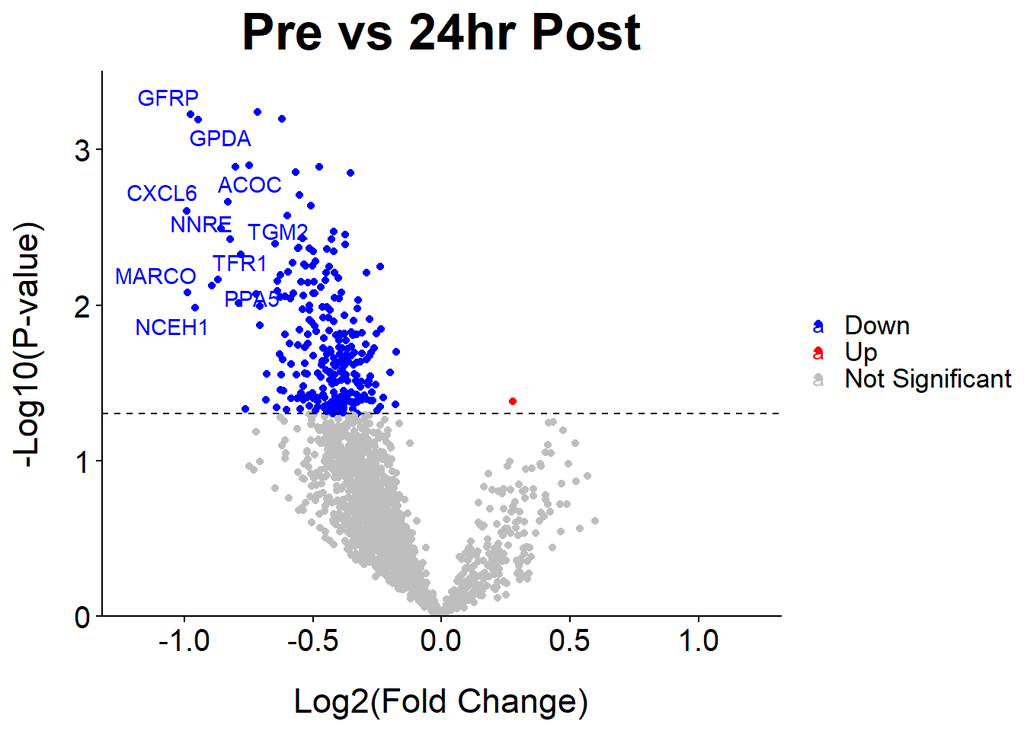

```r
# Create an object holding the pathway to save the plots into
plot.path <- "C:/Users/mnale/OneDrive - University of North Carolina at Chapel Hill/WSP Proteomics Project/output_FINAL/Plots_FINAL"

# Add a column of NAs
FC_Mean$diffexpressed <- "Not Significant"

# If FC > 0 and pvalue < 0.05, set as "Up"
FC_Mean$diffexpressed[FC_Mean$FC_Mean > 0 & FC_Mean$Pval < 0.05] <- "Up"

# If FC < 0 and pvalue < 0.05, set as "Down"
FC_Mean$diffexpressed[FC_Mean$FC_Mean < 0 & FC_Mean$Pval < 0.05] <- "Down"

# Now write Down the name of proteins beside the points...
# Create a new column "delabel" to de, that will contain the name of proteins differentially expressed (NA in case they are not)
FC_Mean$delabel <- NA
FC_Mean$delabel[FC_Mean$diffexpressed != "Not Significant"] <- FC_Mean$Protein_Name[FC_Mean$diffexpressed != "Not Significant"]

# Create the plot
FC_Volcano <- FC_Mean %>%
  ggplot(
    aes(x = FC_Mean, y = -log10(Pval), col = diffexpressed, label = delabel)) +
        geom_point() +
        scale_color_manual(values = c("blue", "red", "gray") , breaks = c("Down", "Up", "Not Significant")) +

        geom_hline(yintercept = -log10(0.05), linetype = "dashed", color = "black") +

        geom_text_repel(data = FC_Mean %>%
            filter(Protein_Name %in% c("CXCL6", "MARCO", "GFRP",  "NCEH1", "GPDA",  "PPA5",  "TFR1",  "NNRE",  "ACOC",  "TGM2" ))) +

        xlim(-1.2, 1.2) +
        scale_y_continuous(expand = c(0, 0), limits = c(0, 3.5)) +

        labs(y = "-Log10(P-value)", x = "Log2(Fold Change)") +
        ggtitle("Pre vs 24hr Post") +

        theme_cowplot(12) +

        theme(
          axis.line = element_line(colour = "black"),

          axis.text = element_text(size = 15) ,
          axis.title  = (element_text(size = 17)),
          axis.title.x = element_text(margin = margin(t = 15)),
          axis.title.y = element_text(margin = margin(r = 15)),

          plot.title = element_text(size = 25, face = "bold", hjust = 0.5),

          legend.title = element_blank(),
          legend.text = element_text(size = 13))

FC_Volcano
```

```r
ggsave(
  "FC_Volcano_06.07.2024.png",
  plot = last_plot(),
  path = plot.path,
  width = 6.5,
  height = 5.25,
  dpi = 1200
)
```

Generate volcano plots that show upregulated and dowregulated proteins stratified by Males and Females. Only FCs with a p<0.05 will be considered significant.

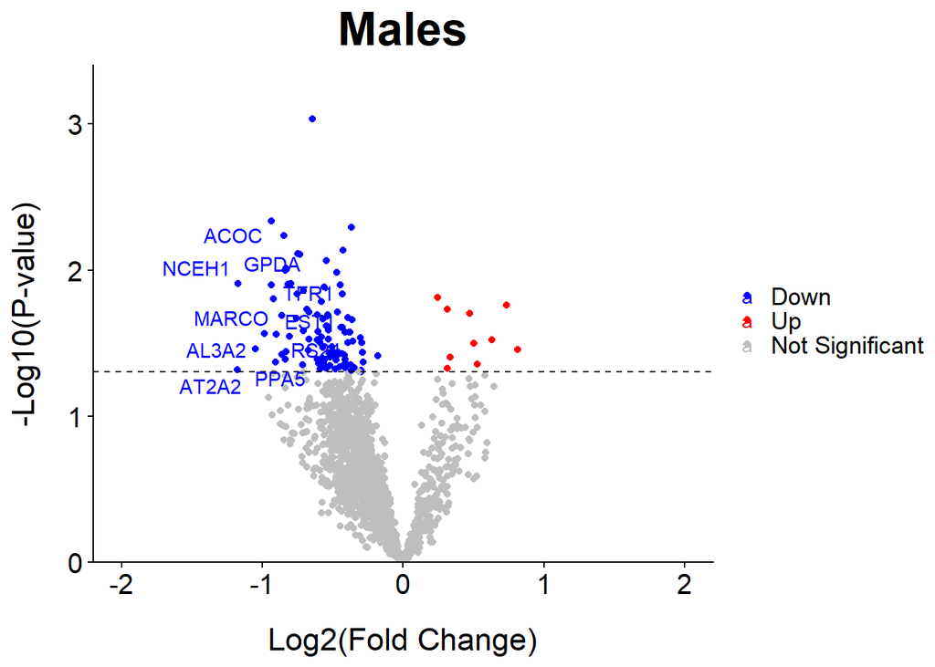

```r
# Select for male subjects.
M_FC <- FC_Sex %>%
   select(c(Protein_Name, M_FC_Mean, M_Pval))

# Add a column of NAs
M_FC$diffexpressed <- "Not Significant"

# If FC > 0 and pvalue < 0.05, set as "Up"
M_FC$diffexpressed[M_FC$M_FC_Mean > 0 & M_FC$M_Pval < 0.05] <- "Up"

# If FC < -0.6 and pvalue < 0.05, set as "Down"
M_FC$diffexpressed[M_FC$M_FC_Mean < 0 & M_FC$M_Pval < 0.05] <- "Down"

# Now write Down the name of proteins beside the points...
# Create a new column "delabel" to de, that will contain the name of proteins differentially expressed (NA in case they are not)
M_FC$delabel <- NA
M_FC$delabel[M_FC$diffexpressed != "Not Significant"] <- M_FC$Protein_Name[M_FC$diffexpressed != "Not Significant"]

# Create the plot
M_Volcano <- M_FC %>%
  ggplot(
    aes(x = M_FC_Mean, y = -log10(M_Pval), col = diffexpressed, label = delabel)) +
        geom_point() +
        scale_color_manual(values = c("blue", "red", "gray") , breaks = c("Down", "Up", "Not Significant")) +
        geom_hline(yintercept = -log10(0.05), linetype = "dashed", color = "black") +

        geom_text_repel(data = M_FC %>%
          filter(Protein_Name %in% c("AT2A2", "NCEH1", "AL3A2", "MARCO", "GPDA", "ACOC",  "TFR1",  "PPA5",  "EST1",  "RS24"))) +

        xlim(-2, 2) +
        scale_y_continuous(expand = c(0, 0), limits = c(0, 3.4)) +

        labs(y = "-Log10(P-value)", x = "Log2(Fold Change)") +
        ggtitle("Males") +

        theme_cowplot(12) +

        theme(
          axis.line = element_line(colour = "black"),

          axis.text = element_text(size = 15) , axis.title  = (element_text(size = 17)),
          axis.title.x = element_text(margin = margin(t = 15)),
          axis.title.y = element_text(margin = margin(r = 15)),

          plot.title = element_text(size = 25, face = "bold", hjust = 0.5),

          legend.text = element_text(size = 13),
          legend.title = element_blank())
M_Volcano
```